# Pertemuan 7 - Penanganan Kondisi Tak Standar dan Seleksi Peubah

Pada pertemuan sebelumnya, kita sudah membahas terkait diagnostik dan asumsi sisaan yang harus dipenuhi dari model regresi linear. Asumsi-asumsi tersebut tidak lain adalah sebagai berikut,

1. Nilai harapan galat sama dengan nol $(E[\varepsilon_i]=0)$
2. Homoskedastisitas atau ragam galat homogen $(var[\varepsilon]=\sigma^2I)$
3. Autokorelasi atau galat saling bebas $(E[\varepsilon_i,\varepsilon_j]=0)$
4. Galat menyebar Normal $(\varepsilon∼N(0,\sigma^2I))$
5. Tidak ada multikolinearitas antarpeubah bebas $(cov(x_i,x_j)=0,\forall{i}\neq{j})$

Jika ditemukan adanya asumsi-asumsi yang dilanggar pada proses analisis, diperlukan adanya penanganan kondisi tak standar. Pada pertemuan kali ini, akan dibahas penanganan kondisi tak standar sederhana pada dataset `state.x77`.

```r
library(dplyr)
data <- as.data.frame(state.x77)
data <- data %>% dplyr::select(Income, everything())
data <- data[,-7]

data
```

```
##                Income Population Illiteracy Life Exp Murder HS Grad   Area
## Alabama          3624       3615        2.1    69.05   15.1    41.3  50708
## Alaska           6315        365        1.5    69.31   11.3    66.7 566432
## Arizona          4530       2212        1.8    70.55    7.8    58.1 113417
## Arkansas         3378       2110        1.9    70.66   10.1    39.9  51945
## California       5114      21198        1.1    71.71   10.3    62.6 156361
## Colorado         4884       2541        0.7    72.06    6.8    63.9 103766
## Connecticut      5348       3100        1.1    72.48    3.1    56.0   4862
## Delaware         4809        579        0.9    70.06    6.2    54.6   1982
## Florida          4815       8277        1.3    70.66   10.7    52.6  54090
## Georgia          4091       4931        2.0    68.54   13.9    40.6  58073
## Hawaii           4963        868        1.9    73.60    6.2    61.9   6425
## Idaho            4119        813        0.6    71.87    5.3    59.5  82677
## Illinois         5107      11197        0.9    70.14   10.3    52.6  55748
## Indiana          4458       5313        0.7    70.88    7.1    52.9  36097
## Iowa             4628       2861        0.5    72.56    2.3    59.0  55941
## Kansas           4669       2280        0.6    72.58    4.5    59.9  81787
## Kentucky         3712       3387        1.6    70.10   10.6    38.5  39650
## Louisiana        3545       3806        2.8    68.76   13.2    42.2  44930
## Maine            3694       1058        0.7    70.39    2.7    54.7  30920
## Maryland         5299       4122        0.9    70.22    8.5    52.3   9891
## Massachusetts    4755       5814        1.1    71.83    3.3    58.5   7826
## Michigan         4751       9111        0.9    70.63   11.1    52.8  56817
## Minnesota        4675       3921        0.6    72.96    2.3    57.6  79289
## Mississippi      3098       2341        2.4    68.09   12.5    41.0  47296
## Missouri         4254       4767        0.8    70.69    9.3    48.8  68995
## Montana          4347        746        0.6    70.56    5.0    59.2 145587
## Nebraska         4508       1544        0.6    72.60    2.9    59.3  76483
## Nevada           5149        590        0.5    69.03   11.5    65.2 109889
## New Hampshire    4281        812        0.7    71.23    3.3    57.6   9027
## New Jersey       5237       7333        1.1    70.93    5.2    52.5   7521
## New Mexico       3601       1144        2.2    70.32    9.7    55.2 121412
## New York         4903      18076        1.4    70.55   10.9    52.7  47831
## North Carolina   3875       5441        1.8    69.21   11.1    38.5  48798
## North Dakota     5087        637        0.8    72.78    1.4    50.3  69273
## Ohio             4561      10735        0.8    70.82    7.4    53.2  40975
## Oklahoma         3983       2715        1.1    71.42    6.4    51.6  68782
## Oregon           4660       2284        0.6    72.13    4.2    60.0  96184
## Pennsylvania     4449      11860        1.0    70.43    6.1    50.2  44966
## Rhode Island     4558        931        1.3    71.90    2.4    46.4   1049
## South Carolina   3635       2816        2.3    67.96   11.6    37.8  30225
## South Dakota     4167        681        0.5    72.08    1.7    53.3  75955
## Tennessee        3821       4173        1.7    70.11   11.0    41.8  41328
## Texas            4188      12237        2.2    70.90   12.2    47.4 262134
## Utah             4022       1203        0.6    72.90    4.5    67.3  82096
## Vermont          3907        472        0.6    71.64    5.5    57.1   9267
## Virginia         4701       4981        1.4    70.08    9.5    47.8  39780
## Washington       4864       3559        0.6    71.72    4.3    63.5  66570
## West Virginia    3617       1799        1.4    69.48    6.7    41.6  24070
## Wisconsin        4468       4589        0.7    72.48    3.0    54.5  54464
## Wyoming          4566        376        0.6    70.29    6.9    62.9  97203
```

# Pemodelan Regresi Linear

## Eksplorasi Data

Eksplorasi paling dasar dalam proses analisis regresi adalah pengecekan sebaran tiap peubah dan deteksi potensi amatan anomali (pencilan maupun leverage). Tiap peubah tentunya diharapkan menyebar (atau menyerupai sebaran) Normal dan bebas dari amatan anomali.

```r
library(GGally)
```

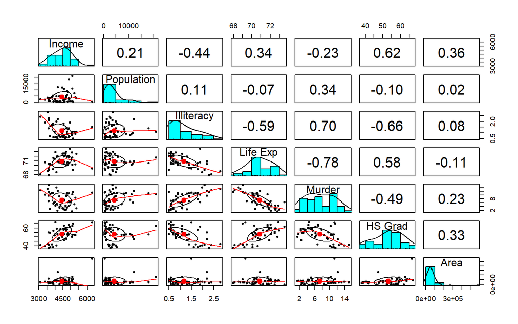

```r
library(psych)

pairs.panels(data)
```

## Pemodelan Regresi Linear

```r
formula1 <- Income~.
```

```r
library(car)
model <- lm(formula1, data=data)
(vif_model <- vif(model))
```

```
## Population Illiteracy `Life Exp`     Murder  `HS Grad`       Area
##   1.368406   2.974850   3.510591   4.852331   2.955145   1.539652
```

Setelah dilakukan pengujian, diketahui bahwa tidak terdapat multikolinearitas antarpeubah penjelas. **Hal ini diindikasikan oleh nilai VIF < 10 pada seluruh peubah penjelas yang digunakan.**

```r
summary(model)
```

```
##
## Call:
## lm(formula = formula1, data = data)
##
## Residuals:
##     Min      1Q  Median      3Q     Max
## -896.22 -229.39  -51.62  233.70  963.04
##
## Coefficients:
##               Estimate Std. Error t value Pr(>|t|)
## (Intercept)  3.411e+03  6.457e+03   0.528   0.6000
## Population   3.960e-02  1.739e-02   2.277   0.0278 *
## Illiteracy  -1.557e+02  1.878e+02  -0.829   0.4116
## `Life Exp`  -1.114e+01  9.265e+01  -0.120   0.9048
## Murder      -1.255e+01  3.961e+01  -0.317   0.7529
## `HS Grad`    3.392e+01  1.413e+01   2.401   0.0208 *
## Area         1.690e-03  9.653e-04   1.751   0.0872 .
## ---
## Signif. codes:  0 '***' 0.001 '**' 0.01 '*' 0.05 '.' 0.1 ' ' 1
##
## Residual standard error: 464.7 on 43 degrees of freedom
## Multiple R-squared:  0.4982, Adjusted R-squared:  0.4281
## F-statistic: 7.114 on 6 and 43 DF,  p-value: 2.618e-05
```

Pemodelan menggunakan seluruh peubah menyiratkan bahwa terdapat beberapa peubah penjelas yang tidak berpengaruh signifikan dalam taraf nyata $5\%$ terhadap peubah respons. Jika kita mengharapkan pembentukan model regresi yang terbaik dan mampu menghasilkan informasi terkait peubah-peubah yang memengaruhi peubah respons, perlu dilakukan seleksi peubah pada model yang kita bangun. Terdapat setidaknya tiga metode seleksi peubah yang sering digunakan, yaitu metode *backward*, *forward*, dan *stepwise*.

# Seleksi Peubah

## Metode Backward

Prosedur seleksi peubah dengan metode *backward* berjalan sebagai berikut,

```r
step(lm(formula1, data=data),direction="backward")
```

```
## Start:  AIC=620.59
## Income ~ Population + Illiteracy + `Life Exp` + Murder + `HS Grad` +
##     Area
##
##              Df Sum of Sq      RSS    AIC
## - `Life Exp`  1      3123  9287803 618.61
## - Murder      1     21669  9306348 618.71
## - Illiteracy  1    148423  9433102 619.39
## <none>                     9284679 620.59
## - Area        1    661657  9946336 622.03
## - Population  1   1119285 10403965 624.28
## - `HS Grad`   1   1244587 10529267 624.88
##
## Step:  AIC=618.61
## Income ~ Population + Illiteracy + Murder + `HS Grad` + Area
##
##              Df Sum of Sq      RSS    AIC
## - Murder      1     22308  9310111 616.73
## - Illiteracy  1    165140  9452943 617.49
## <none>                     9287803 618.61
## - Area        1    677009  9964812 620.13
## - Population  1   1236798 10524600 622.86
## - `HS Grad`   1   1416372 10704174 623.71
##
## Step:  AIC=616.73
## Income ~ Population + Illiteracy + `HS Grad` + Area
##
##              Df Sum of Sq      RSS    AIC
## - Illiteracy  1    307844  9617955 616.36
## <none>                     9310111 616.73
## - Area        1    670178  9980289 618.20
## - Population  1   1306229 10616339 621.29
## - `HS Grad`   1   1555728 10865839 622.46
##
## Step:  AIC=616.36
## Income ~ Population + `HS Grad` + Area
##
##              Df Sum of Sq      RSS    AIC
## <none>                     9617955 616.36
## - Area        1    418138 10036092 616.48
## - Population  1   1262741 10880696 620.52
## - `HS Grad`   1   5700334 15318289 637.63
```

```
##
## Call:
## lm(formula = Income ~ Population + `HS Grad` + Area, data = data)
##
## Coefficients:
## (Intercept)   Population    `HS Grad`         Area
##   1.807e+03    3.620e-02    4.508e+01    1.150e-03
```

Berdasarkan prosedur seleksi peubah dengan metode *backward*, model terbaik yang terbentuk adalah model dengan tiga peubah penjelas. Ketiga peubah penjelas itu adalah Population, HS Grad, dan Area.

## Metode Forward

Prosedur seleksi peubah dengan metode *forward* berjalan sebagai berikut,

1. Langkah dimulai dengan melakukan pemodelan hanya terhadap intersep
2. Selanjutnya, satu per satu peubah penjelas akan dimasukkan ke model berdasarkan nilai koefisien korelasi yang paling besar terhadap peubah respons
3. Peubah penjelas yang telah dimasukkan tidak akan dieliminasi dari model
4. Imputasi peubah penjelas terus dilakukan hingga diperoleh model terbaik berdasarkan metrik yang diacu (biasanya AIC)

```r
step(lm(Income~1,data=data),direction="forward",
     scope=~Population + Illiteracy + `Life Exp` + Murder + `HS Grad` + Area)
```

```
## Start:  AIC=643.07
## Income ~ 1
##
##              Df Sum of Sq      RSS    AIC
## + `HS Grad`   1   7110267 11390825 620.81
## + Illiteracy  1   3534351 14966741 634.47
## + Area        1   2442109 16058983 637.99
## + `Life Exp`  1   2141940 16359152 638.91
## + Murder      1    979368 17521724 642.35
## + Population  1    802184 17698908 642.85
## <none>                    18501092 643.07
##
## Step:  AIC=620.81
## Income ~ `HS Grad`
##
##              Df Sum of Sq      RSS    AIC
## + Population  1   1354732 10036092 616.48
## + Area        1    510129 10880696 620.52
## <none>                    11390825 620.81
## + Murder      1    127398 11263427 622.25
## + Illiteracy  1     28654 11362170 622.69
## + `Life Exp`  1     11969 11378856 622.76
##
## Step:  AIC=616.48
## Income ~ `HS Grad` + Population
##
##              Df Sum of Sq      RSS    AIC
## + Area        1    418138  9617955 616.36
## <none>                    10036092 616.48
## + Illiteracy  1     55804  9980289 618.20
## + `Life Exp`  1      8837 10027256 618.44
## + Murder      1      1733 10034359 618.48
##
## Step:  AIC=616.36
## Income ~ `HS Grad` + Population + Area
##
##              Df Sum of Sq     RSS    AIC
## <none>                    9617955 616.36
## + Illiteracy  1    307844 9310111 616.73
## + Murder      1    165012 9452943 617.49
## + `Life Exp`  1     30414 9587541 618.20
```

```
##
## Call:
## lm(formula = Income ~ `HS Grad` + Population + Area, data = data)
##
## Coefficients:
## (Intercept)    `HS Grad`   Population         Area
##   1.807e+03    4.508e+01    3.620e-02    1.150e-03
```

Berdasarkan prosedur seleksi peubah dengan metode *forward*, model terbaik yang terbentuk adalah model dengan tiga peubah penjelas. Ketiga peubah penjelas itu adalah HS Grad, Population, dan Area.

## Metode Stepwise

Sementara itu, prosedur seleksi peubah *stepwise* merupakan kombinasi antara metode *backward* dan *forward*. Model pertama yang dibentuk adalah model dengan seluruh peubah penjelas yang kemudian akan dieliminasi satu per satu. Meskipun demikian, peubah yang telah dieliminasi masih memiliki kemungkinan untuk diimputasi kembali ke dalam model.

```r
step(lm(formula1,data=data),direction="both")
```

```
## Start:  AIC=620.59
## Income ~ Population + Illiteracy + `Life Exp` + Murder + `HS Grad` +
##     Area
##
##              Df Sum of Sq      RSS    AIC
## - `Life Exp`  1      3123  9287803 618.61
## - Murder      1     21669  9306348 618.71
## - Illiteracy  1    148423  9433102 619.39
## <none>                     9284679 620.59
## - Area        1    661657  9946336 622.03
## - Population  1   1119285 10403965 624.28
## - `HS Grad`   1   1244587 10529267 624.88
##
## Step:  AIC=618.61
## Income ~ Population + Illiteracy + Murder + `HS Grad` + Area
##
##              Df Sum of Sq      RSS    AIC
## - Murder      1     22308  9310111 616.73
## - Illiteracy  1    165140  9452943 617.49
## <none>                     9287803 618.61
## - Area        1    677009  9964812 620.13
## + `Life Exp`  1      3123  9284679 620.59
## - Population  1   1236798 10524600 622.86
## - `HS Grad`   1   1416372 10704174 623.71
##
## Step:  AIC=616.73
## Income ~ Population + Illiteracy + `HS Grad` + Area
##
##              Df Sum of Sq      RSS    AIC
## - Illiteracy  1    307844  9617955 616.36
## <none>                     9310111 616.73
## - Area        1    670178  9980289 618.20
## + Murder      1     22308  9287803 618.61
## + `Life Exp`  1      3762  9306348 618.71
## - Population  1   1306229 10616339 621.29
## - `HS Grad`   1   1555728 10865839 622.46
##
## Step:  AIC=616.36
## Income ~ Population + `HS Grad` + Area
##
##              Df Sum of Sq      RSS    AIC
## <none>                     9617955 616.36
## - Area        1    418138 10036092 616.48
## + Illiteracy  1    307844  9310111 616.73
## + Murder      1    165012  9452943 617.49
## + `Life Exp`  1     30414  9587541 618.20
## - Population  1   1262741 10880696 620.52
## - `HS Grad`   1   5700334 15318289 637.63
```

```
##
## Call:
## lm(formula = Income ~ Population + `HS Grad` + Area, data = data)
##
## Coefficients:
## (Intercept)   Population    `HS Grad`         Area
##   1.807e+03    3.620e-02    4.508e+01    1.150e-03
```

Berdasarkan prosedur seleksi peubah dengan metode *stepwise*, model terbaik yang terbentuk adalah model dengan tiga peubah penjelas. Ketiga peubah penjelas itu adalah Population, HS Grad, dan Area.

## Diagnostik Sisaan Model Terbaik

Selanjutnya akan dibentuk model terbaik, yaitu model yang telah melalui prosedur seleksi peubah. Sisaan model ini kemudian akan didiagnostik menggunakan beberapa uji formal.

```r
model2 <- lm(formula = Income ~ Population + `HS Grad` + Area, data = data)
summary(model2)
```

```
##
## Call:
## lm(formula = Income ~ Population + `HS Grad` + Area, data = data)
##
## Residuals:
##     Min      1Q  Median      3Q     Max
## -956.47 -225.60  -14.54  198.88  974.12
##
## Coefficients:
##              Estimate Std. Error t value Pr(>|t|)
## (Intercept) 1.807e+03  4.581e+02   3.944 0.000272 ***
## Population  3.620e-02  1.473e-02   2.458 0.017820 *
## `HS Grad`   4.508e+01  8.634e+00   5.221 4.17e-06 ***
## Area        1.150e-03  8.135e-04   1.414 0.164049
## ---
## Signif. codes:  0 '***' 0.001 '**' 0.01 '*' 0.05 '.' 0.1 ' ' 1
##
## Residual standard error: 457.3 on 46 degrees of freedom
## Multiple R-squared:  0.4801, Adjusted R-squared:  0.4462
## F-statistic: 14.16 on 3 and 46 DF,  p-value: 1.137e-06
```

### Autokorelasi: Durbin-Watson

Uji formal untuk mendeteksi autokorelasi sisaan dapat dilakukan dengan uji Durbin-Watson menggunakan fungsi `durbinWatsonTest`. Uji ini memiliki hipotesis sebagai berikut,

$H_0:E[\varepsilon_i,\varepsilon_j]=0$ (tidak ada autokorelasi)

$H_1:E[\varepsilon_i,\varepsilon_j]\neq0$ (terdapat autokorelasi)

```r
(uji_autokol2 <- durbinWatsonTest(model2,
                                 alternative="two.sided"))
```

```
##  lag Autocorrelation D-W Statistic p-value
##    1     -0.01833158      2.026765   0.934
##  Alternative hypothesis: rho != 0
```

```r
ifelse(uji_autokol2$p < 0.05, "Ada Autokorelasi", "Tidak Ada Autokorelasi")
```

```
## [1] "Tidak Ada Autokorelasi"
```

Nilai p-value $> 0,05$ bermakna taktolak $H_0$. Hal ini mengindikasikan bahwa dalam taraf nyata $5\%$, tidak cukup bukti untuk menyatakan bahwa terdapat autokorelasi dalam sisaan.

### Homogenitas: Breusch-Pagan

Uji formal untuk mendeteksi homogenitas ragam sisaan dapat dilakukan dengan uji Breusch-Pagan menggunakan fungsi `bptest`. Uji ini memiliki hipotesis sebagai berikut,

$H_0:var[\varepsilon]=\sigma^2I$ (ragam homogen)

$H_1:var[\varepsilon]\neq\sigma^2I$ (ragam tidak homogen)

```r
library(lmtest)
(homogen_model2 <- bptest(model2))
```

```
##
##  studentized Breusch-Pagan test
##
## data:  model2
## BP = 3.3253, df = 3, p-value = 0.3441
```

```r
ifelse(homogen_model2$p.value < 0.05, "Ragam Tidak Homogen", "Ragam Homogen")
```

```
##              BP
## "Ragam Homogen"
```

Nilai p-value $>0,05$ bermakna taktolak $H_0$. Hal ini mengindikasikan bahwa dalam taraf nyata $5\%$, tidak cukup bukti untuk menyatakan bahwa ragam sisaan tidak homogen.

### Normalitas: Kolmogorov-Smirnov

Uji formal untuk mendeteksi normalitas sisaan dapat dilakukan dengan uji Kolmogorov-Smirnov menggunakan fungsi `lillie.test`. Menghitung perbedaan maksimum antara distribusi kumulatif empiris dari data sampel dan distribusi kumulatif dari distribusi normal yang diharapkan. Uji ini memiliki hipotesis sebagai berikut,

$H_0:F(x)=F_0(x)$ (sisaan menyebar Normal)

$H_1:F(x)\neq{F_0(x)}$ (sisaan tidak menyebar Normal)

```r
library(nortest)
sisaan_model2 <- resid(model2)
(norm_model2 <- lillie.test(sisaan_model2))
```

```
##
##  Lilliefors (Kolmogorov-Smirnov) normality test
##
## data:  sisaan_model2
## D = 0.14525, p-value = 0.01007
```

```r
ifelse(norm_model2$p.value < 0.05, "Sisaan Tidak Menyebar Normal", "Sisaan Menyebar Normal")
```

```
## [1] "Sisaan Tidak Menyebar Normal"
```

Nilai p-value $<0,05$ bermakna tolak $H_0$. Hal ini mengindikasikan bahwa dalam taraf nyata $5\%$, cukup bukti untuk menyatakan bahwa sisaan tidak menyebar Normal.

### Normalitas: Shapiro-Wilk

Uji formal untuk mendeteksi normalitas sisaan juga dapat dilakukan dengan uji Shapiro-Wilk menggunakan fungsi `shapiro.test`. Khusus dirancang untuk menguji normalitas dan lebih sensitif terhadap penyimpangan dari normalitas, terutama untuk sampel kecil.

```r
(norm2_model2 <- shapiro.test(sisaan_model2))
```

```
##
##  Shapiro-Wilk normality test
##
## data:  sisaan_model2
## W = 0.9611, p-value = 0.09886
```

```r
ifelse(norm2_model2$p.value < 0.05, "Sisaan Tidak Menyebar Normal", "Sisaan Menyebar Normal")
```

```
## [1] "Sisaan Menyebar Normal"
```

Nilai p-value $>0,05$ bermakna terima $H_0$. Hal ini mengindikasikan bahwa dalam taraf nyata $5\%$, cukup bukti untuk menyatakan bahwa sisaan menyebar Normal.

# Penanganan Kondisi Tak Standar

## Transformasi Box-Cox

Salah satu langkah penanganan kondisi takstandar berupa normalitas sisaan adalah transformasi peubah respons. Metode transformasi yang sering kali digunakan adalah metode Box-Cox menggunakan fungsi `boxcox` dengan rumus transformasi sebagai berikut.

$$\begin{equation}
y(\lambda)=\begin{cases}
\frac{y^\lambda-1}{\lambda}, & \text{if}\space\lambda\neq0;\\
log\space{y}, & \text{if}\space\lambda=0.
\end{cases}
\end{equation}$$

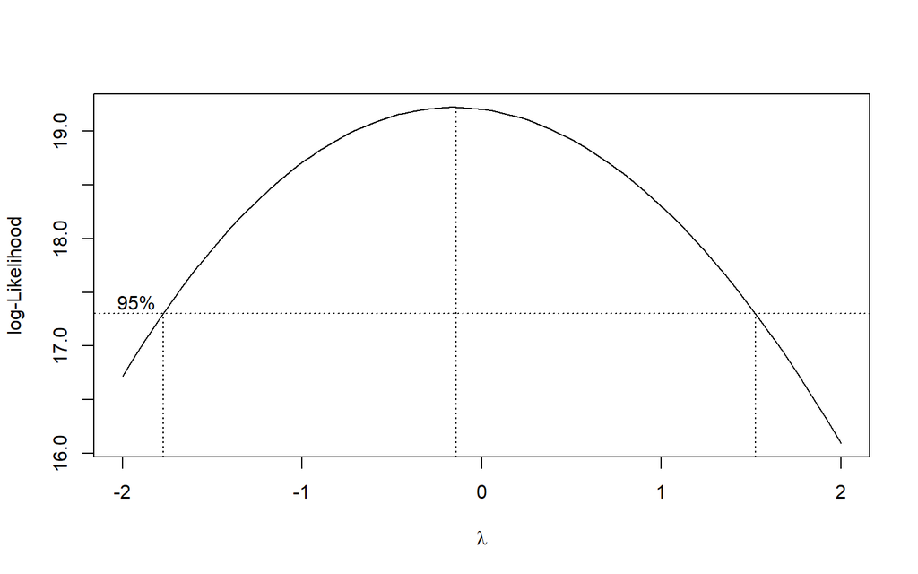

```r
library(MASS)

bc_model <- boxcox(formula1, data=data,
                   lambda = seq(-2,2,by=0.1))
```

```r
(optimal_lambda <- bc_model$x[which.max(bc_model$y)])
```

```
## [1] -0.1414141
```

Parameter $\lambda$ optimum dapat diketahui dengan melihat nilai yang memaksimumkan fungsi log-Likelihood di atas. Berdasarkan grafik di atas, diketahui bahwa $\lambda$ optimum bernilai -0,1414… Selanjutnya proses transformasi peubah respons dilakukan dengan kriteria sebagai berikut,

Tabel Transformasi Peubah Respons Box-Cox

| $\lambda$ | Transformasi |
| --- | --- |
| 2 | $Y^2$ |
| 0,5 | $\sqrt{Y}$ |
| 0 | $log\space{Y}\text{ atau }ln\space{Y}$ |
| -0,5 | $1/\sqrt{Y}$ |
| -1 | $1/Y$ |

Berdasarkan nilai $\lambda$ optimum yang diperoleh, transformasi pada peubah respons yang dilakukan adalah sebagai berikut,

```r
data$Income_trf <- ((data$Income)^optimal_lambda)/optimal_lambda
```

```r
(data2 <- data[,-1] %>% dplyr::select(Income_trf, everything()))
```

```
##                Income_trf Population Illiteracy Life Exp Murder HS Grad   Area
## Alabama         -2.219155       3615        2.1    69.05   15.1    41.3  50708
## Alaska          -2.051543        365        1.5    69.31   11.3    66.7 566432
## Arizona         -2.150221       2212        1.8    70.55    7.8    58.1 113417
## Arkansas        -2.241325       2110        1.9    70.66   10.1    39.9  51945
## California      -2.113664      21198        1.1    71.71   10.3    62.6 156361
## Colorado        -2.127463       2541        0.7    72.06    6.8    63.9 103766
## Connecticut     -2.100333       3100        1.1    72.48    3.1    56.0   4862
## Delaware        -2.132124        579        0.9    70.06    6.2    54.6   1982
## Florida         -2.131749       8277        1.3    70.66   10.7    52.6  54090
## Georgia         -2.181441       4931        2.0    68.54   13.9    40.6  58073
## Hawaii          -2.122642        868        1.9    73.60    6.2    61.9   6425
## Idaho           -2.179337        813        0.6    71.87    5.3    59.5  82677
## Illinois        -2.114073      11197        0.9    70.14   10.3    52.6  55748
## Indiana         -2.155099       5313        0.7    70.88    7.1    52.9  36097
## Iowa            -2.143723       2861        0.5    72.56    2.3    59.0  55941
## Kansas          -2.141051       2280        0.6    72.58    4.5    59.9  81787
## Kentucky        -2.211638       3387        1.6    70.10   10.6    38.5  39650
## Louisiana       -2.226082       3806        2.8    68.76   13.2    42.2  44930
## Maine           -2.213159       1058        0.7    70.39    2.7    54.7  30920
## Maryland        -2.103069       4122        0.9    70.22    8.5    52.3   9891
## Massachusetts   -2.135532       5814        1.1    71.83    3.3    58.5   7826
## Michigan        -2.135786       9111        0.9    70.63   11.1    52.8  56817
## Minnesota       -2.140662       3921        0.6    72.96    2.3    57.6  79289
## Mississippi     -2.268918       2341        2.4    68.09   12.5    41.0  47296
## Missouri        -2.169421       4767        0.8    70.69    9.3    48.8  68995
## Montana         -2.162797        746        0.6    70.56    5.0    59.2 145587
## Nebraska        -2.151702       1544        0.6    72.60    2.9    59.3  76483
## Nevada          -2.111626        590        0.5    69.03   11.5    65.2 109889
## New Hampshire   -2.167481        812        0.7    71.23    3.3    57.6   9027
## New Jersey      -2.106572       7333        1.1    70.93    5.2    52.5   7521
## New Mexico      -2.221154       1144        2.2    70.32    9.7    55.2 121412
## New York        -2.126296      18076        1.4    70.55   10.9    52.7  47831
## North Carolina  -2.198238       5441        1.8    69.21   11.1    38.5  48798
## North Dakota    -2.115247        637        0.8    72.78    1.4    50.3  69273
## Ohio            -2.148149      10735        0.8    70.82    7.4    53.2  40975
## Oklahoma        -2.189710       2715        1.1    71.42    6.4    51.6  68782
## Oregon          -2.141635       2284        0.6    72.13    4.2    60.0  96184
## Pennsylvania    -2.155715      11860        1.0    70.43    6.1    50.2  44966
## Rhode Island    -2.148348        931        1.3    71.90    2.4    46.4   1049
## South Carolina  -2.218204       2816        2.3    67.96   11.6    37.8  30225
## South Dakota    -2.175770        681        0.5    72.08    1.7    53.3  75955
## Tennessee       -2.202605       4173        1.7    70.11   11.0    41.8  41328
## Texas           -2.174224      12237        2.2    70.90   12.2    47.4 262134
## Utah            -2.186694       1203        0.6    72.90    4.5    67.3  82096
## Vermont         -2.195683        472        0.6    71.64    5.5    57.1   9267
## Virginia        -2.138984       4981        1.4    70.08    9.5    47.8  39780
## Washington      -2.128698       3559        0.6    71.72    4.3    63.5  66570
## West Virginia   -2.219762       1799        1.4    69.48    6.7    41.6  24070
## Wisconsin       -2.154416       4589        0.7    72.48    3.0    54.5  54464
## Wyoming         -2.147816        376        0.6    70.29    6.9    62.9  97203
```

## Diagnostik Sisaan Hasil Transformasi

Selanjutnya dilakukan pemodelan dan diagnostik sisaan kembali pada data baru dengan peubah respons yang sudah ditransformasi.

```r
formula2 <- Income_trf~Population + `HS Grad` + Area
```

```r
model3 <- lm(formula2, data=data2)
summary(model3)
```

```
##
## Call:
## lm(formula = formula2, data = data2)
##
## Residuals:
##       Min        1Q    Median        3Q       Max
## -0.066599 -0.015855 -0.000915  0.015086  0.063990
##
## Coefficients:
##               Estimate Std. Error t value Pr(>|t|)
## (Intercept) -2.353e+00  3.155e-02 -74.567  < 2e-16 ***
## Population   2.720e-06  1.014e-06   2.681   0.0102 *
## `HS Grad`    3.354e-03  5.947e-04   5.641 9.98e-07 ***
## Area         4.531e-08  5.603e-08   0.809   0.4228
## ---
## Signif. codes:  0 '***' 0.001 '**' 0.01 '*' 0.05 '.' 0.1 ' ' 1
##
## Residual standard error: 0.0315 on 46 degrees of freedom
## Multiple R-squared:  0.4925, Adjusted R-squared:  0.4594
## F-statistic: 14.88 on 3 and 46 DF,  p-value: 6.625e-07
```

### Autokorelasi: Durbin-Watson

```r
(uji_autokol3 <- durbinWatsonTest(model3,
                                  alternative="two.sided"))
```

```
##  lag Autocorrelation D-W Statistic p-value
##    1     -0.01316917      2.017166   0.948
##  Alternative hypothesis: rho != 0
```

```r
ifelse(uji_autokol3$p < 0.05, "Ada Autokorelasi", "Tidak Ada Autokorelasi")
```

```
## [1] "Tidak Ada Autokorelasi"
```

### Homogenitas: Breusch-Pagan

```r
library(lmtest)
(homogen_model3 <- bptest(model3))
```

```
##
##  studentized Breusch-Pagan test
##
## data:  model3
## BP = 2.2361, df = 3, p-value = 0.5249
```

```r
ifelse(homogen_model3$p.value < 0.05, "Ragam Tidak Homogen", "Ragam Homogen")
```

```
##              BP
## "Ragam Homogen"
```

### Normalitas: Kolomogorov-Smirnov

```r
library(nortest)
sisaan_model3 <- resid(model3)
(norm_model3 <- lillie.test(sisaan_model3))
```

```
##
##  Lilliefors (Kolmogorov-Smirnov) normality test
##
## data:  sisaan_model3
## D = 0.13617, p-value = 0.02129
```

```r
ifelse(norm_model3$p.value < 0.05, "Sisaan Tidak Menyebar Normal", "Sisaan Menyebar Normal")
```

```
## [1] "Sisaan Tidak Menyebar Normal"
```

# Transformasi Balik

Jika ingin mengembalikan model untuk menjelaskan peubah respons sebelum ditransformasi, perlu dilakukan transformasi balik pada model yang dibentuk. Prosedur transformasi balik dilakukan dengan proses matematika biasa dengan mengutamakan pengubahan peubah respons terlebih dahulu. Proses transformasi balik dapat dicontohkan sebagai berikut,